# Dance Entropy Analysis

Peter Gates

10/30/2019

## Dance Study Entropy Analysis

Entropy has been calculated using MatLab code for 176 biomechanical variables measured through the Noraxon system during dance sessions in participants with Parkinson’s Disease (PD) and control older adults (OA). This document outlines the statistical results.

### Data Cleaning

Data was cleaned using the following criteria:

- Date was extracted from filename and added to new Date column
- Participant ID extracted from filename and added to new Participant column
- Dance Type was extracted from filename and added to new Dance Type column
- Rumba, Swing, Electric Slide data were removed
- New Group column was created where data was organized into “OA” or “PD”
- All values equal to “0” were replaced with “NA”. 0 indicates a failure of the biomechanical sensors and thus are excluded from analysis
- One observation of Tango was removed as there were NA data for any of the variables.

The cleaned data were saved as df_clean.

df_clean was further separated into PD or OA data, for ease of analysis. These are shown below.

```r
df_pd
```

```
## # A tibble: 18 x 14
##    Date                Participant Dance_Type `SamEn_Elbow-LT~
##    <dttm>              <fct>       <fct>                 <dbl>
##  1 2018-07-14 12:20:00 pddance001  Tango              0.000623
##  2 2018-07-14 12:32:00 pddance001  Tango              0.000273
##  3 2018-08-11 11:55:00 pddance002  Line Dance         0.00709
##  4 2018-08-11 12:03:00 pddance002  Foxtrot            0.0530
##  5 2018-08-11 12:08:00 pddance002  Foxtrot            0.0587
##  6 2018-08-11 12:13:00 pddance002  Waltz              0.0434
##  7 2018-08-11 12:19:00 pddance002  Tango              0.0317
##  8 2018-08-11 12:20:00 pddance002  Tango              0.0334
##  9 2018-08-11 12:30:00 pddance002  Tango              0.0105
## 10 2018-10-13 12:11:00 pddance003  Tango              0.0107
## 11 2018-10-13 12:26:00 pddance003  Tango              0.00177
## 12 2018-11-10 12:28:00 pddance005  Tango              0.0164
## 13 2018-11-10 12:34:00 pddance005  Tango              0.00113
## 14 2018-12-08 12:07:00 pddance005  Foxtrot            0.0336
## 15 2018-12-08 12:15:00 pddance005  Foxtrot            0.0929
## 16 2018-12-08 12:19:00 pddance005  Tango              0.0334
## 17 2019-09-14 12:14:00 pddance007  Tango              0.00209
## 18 2019-09-14 12:21:00 pddance007  Tango              0.000611
## # ... with 10 more variables: `SamEn_Elbow-RT-Flexion (deg)` <dbl>,
## #   `SamEn_Hip-LT-Abduction (deg)` <dbl>, `SamEn_Hip-LT-Flexion
## #   (deg)` <dbl>, `SamEn_Hip-LT-Rotation Ext (deg)` <dbl>,
## #   `SamEn_Hip-RT-Abduction (deg)` <dbl>, `SamEn_Hip-RT-Flexion
## #   (deg)` <dbl>, `SamEn_Hip-RT-Rotation Ext (deg)` <dbl>,
## #   `SamEn_Knee-LT-Flexion (deg)` <dbl>, `SamEn_Knee-RT-Flexion
## #   (deg)` <dbl>, Group <fct>
```

```r
df_oa
```

```
## # A tibble: 5 x 14
##   Date                Participant Dance_Type `SamEn_Elbow-LT~
##   <dttm>              <fct>       <fct>                 <dbl>
## 1 2018-10-11 13:38:00 pddancecon~ Line Dance         0.0562
## 2 2018-10-11 13:53:00 pddancecon~ Waltz              0.000248
## 3 2018-10-18 13:41:00 pddancecon~ Foxtrot            0.00407
## 4 2018-10-18 14:03:00 pddancecon~ Tango              0.00398
## 5 2018-10-18 14:39:00 pddancecon~ Tango              0.00268
## # ... with 10 more variables: `SamEn_Elbow-RT-Flexion (deg)` <dbl>,
## #   `SamEn_Hip-LT-Abduction (deg)` <dbl>, `SamEn_Hip-LT-Flexion
## #   (deg)` <dbl>, `SamEn_Hip-LT-Rotation Ext (deg)` <dbl>,
## #   `SamEn_Hip-RT-Abduction (deg)` <dbl>, `SamEn_Hip-RT-Flexion
## #   (deg)` <dbl>, `SamEn_Hip-RT-Rotation Ext (deg)` <dbl>,
## #   `SamEn_Knee-LT-Flexion (deg)` <dbl>, `SamEn_Knee-RT-Flexion
## #   (deg)` <dbl>, Group <fct>
```

### Data Statistics

#### Difference between sides, within dances

##### PD left v right side

Is there a significant difference in left vs right SamEn, per Dance_Type?

H0: left_variable = right_variable

HA: left_variable > right_variable

[output not shown]

PD Line and Waltz did not have enough data for a t test.

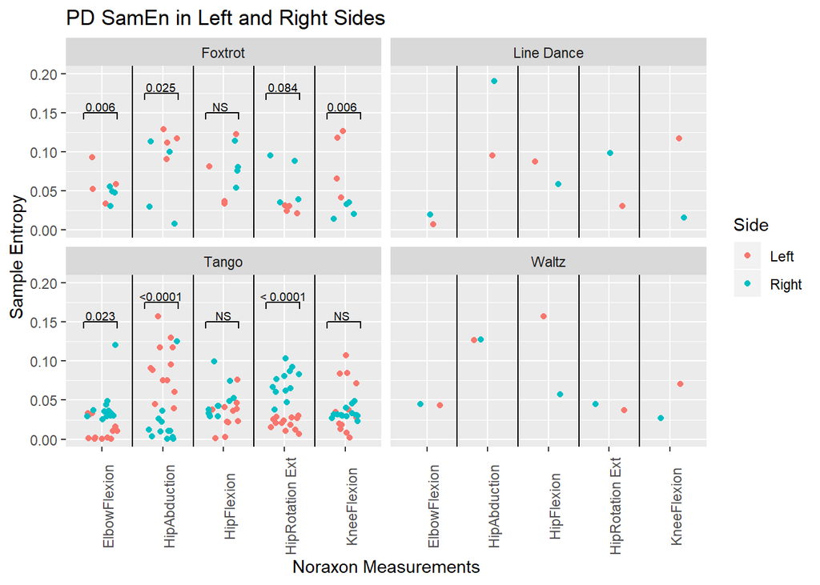

##### OA left v right side

Is there a significant difference in left vs right SamEn, per Dance_Type?

H0: left_variable = right_variable

HA: left_variable > right_variable

[output not shown]

OA Foxtrot, Line and Waltz did not have enough data for a t test.

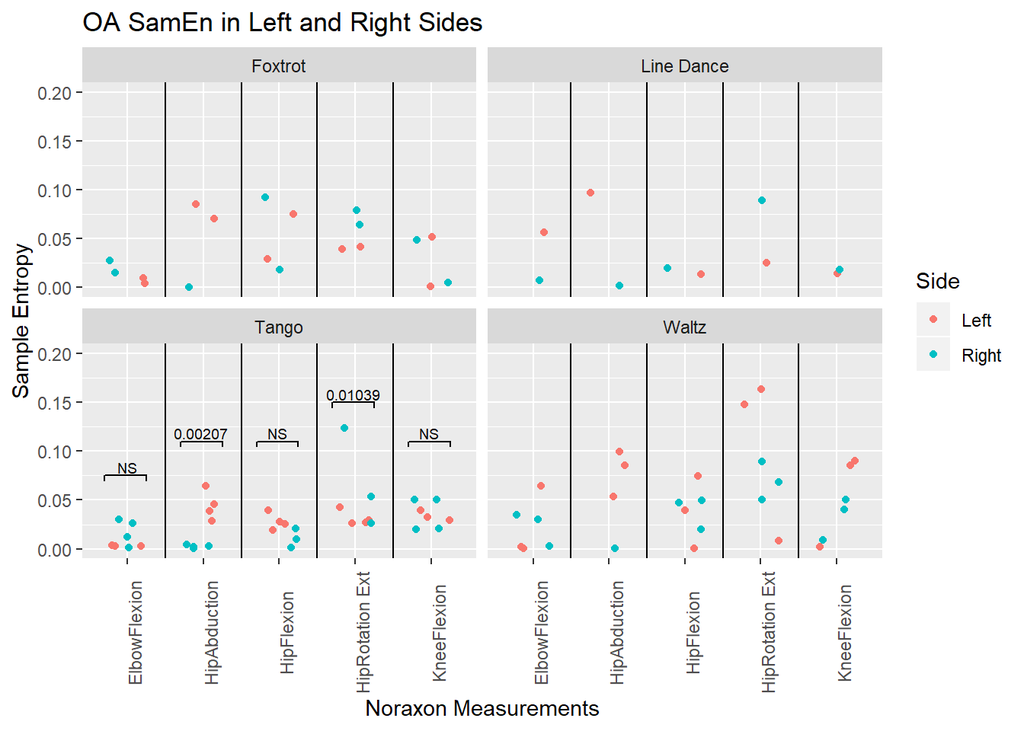

#### Difference amongst dances

A MANOVA was run to determine whether any significant differences exist between dance types in terms of the 10 variables. This turned out to be significant (p < 0.001).

```
##                  Df Pillai approx F num Df den Df   Pr(>F)
## df_pd$Dance_Type  3 2.5543   4.0111     30     21 0.000796 ***
## Residuals        14
## ---
## Signif. codes:  0 '***' 0.001 '**' 0.01 '*' 0.05 '.' 0.1 ' ' 1
```

The dependent variables significantly different between dances include:

- SamEn_Elbow-LT-Flexion (p < 0.01)
- SamEn_Hip-RT-Abduction (p < 0.01)
- SamEn_Knee-LT-Flexion was slightly significant (p < 0.1)

The following only shows the significant results:

```
## [1] "SamEn_Elbow-LT-Flexion"
```

```
##                  Df   Sum Sq   Mean Sq F value  Pr(>F)
## df_pd$Dance_Type  3 0.007473 0.0024911   8.999 0.00142 **
## Residuals        14 0.003875 0.0002768
## ---
## Signif. codes:  0 '***' 0.001 '**' 0.01 '*' 0.05 '.' 0.1 ' ' 1
```

```
## [1] "SamEn_Hip-RT-Abduction"
```

```
##                  Df  Sum Sq  Mean Sq F value  Pr(>F)
## df_pd$Dance_Type  3 0.03579 0.011932   7.924 0.00248 **
## Residuals        14 0.02108 0.001506
## ---
## Signif. codes:  0 '***' 0.001 '**' 0.01 '*' 0.05 '.' 0.1 ' ' 1
```

```
## [1] "SamEn_Knee-LT-Flexion"
```

```
##                  Df  Sum Sq  Mean Sq F value Pr(>F)
## df_pd$Dance_Type  3 0.01017 0.003390    2.54 0.0984 .
## Residuals        14 0.01869 0.001335
## ---
## Signif. codes:  0 '***' 0.001 '**' 0.01 '*' 0.05 '.' 0.1 ' ' 1
```

TukeyHSD was run to determine which dances saw the significant difference in the appropriate SamEn.

- SamEn in LT elbow flexion was significantly different between TANGO and FOXTROT (p = 0.001)
- SamEn in RT hip abduction was significantly different between TANGO and LINE DANCE (p = 0.005), LINE DANCE and FOXTROT (p = 0.046)
- SamEn in LT knee flexion was NOT significantly different between any dances (p > 0.1 for all comparisons)

```
## [1] "SamEn_Elbow-LT-Flexion"
```

```
##   Tukey multiple comparisons of means
##     95% family-wise confidence level
##
## Fit: aov(formula = df_pd$`SamEn_Elbow-LT-Flexion (deg)` ~ df_pd$Dance_Type)
##
## $`df_pd$Dance_Type`
##                            diff         lwr         upr     p adj
## Line Dance-Foxtrot -0.052456068 -0.10652326  0.00161112 0.0585584
## Tango-Foxtrot      -0.047649271 -0.07556945 -0.01972910 0.0010620
## Waltz-Foxtrot      -0.016172970 -0.07024016  0.03789422 0.8203587
## Tango-Line Dance    0.004806797 -0.04552702  0.05514061 0.9921926
## Waltz-Line Dance    0.036283098 -0.03210709  0.10467328 0.4404207
## Waltz-Tango         0.031476301 -0.01885751  0.08181011 0.3061002
```

```
## [1] "SamEn_Hip-RT-Abduction"
```

```
##   Tukey multiple comparisons of means
##     95% family-wise confidence level
##
## Fit: aov(formula = df_pd$`SamEn_Hip-RT-Abduction (deg)` ~ df_pd$Dance_Type)
##
## $`df_pd$Dance_Type`
##                           diff          lwr         upr     p adj
## Line Dance-Foxtrot  0.12788073  0.001780399  0.25398105 0.0463709
## Tango-Foxtrot      -0.04109173 -0.106209664  0.02402619 0.2990083
## Waltz-Foxtrot       0.06476230 -0.061338026  0.19086263 0.4672658
## Tango-Line Dance   -0.16897246 -0.286365478 -0.05157945 0.0045028
## Waltz-Line Dance   -0.06311842 -0.222624125  0.09638727 0.6660919
## Waltz-Tango         0.10585404 -0.011538980  0.22324705 0.0836766
```

```
## [1] "SamEn_Knee-LT-Flexion"
```

```
##   Tukey multiple comparisons of means
##     95% family-wise confidence level
##
## Fit: aov(formula = df_pd$`SamEn_Knee-LT-Flexion (deg)` ~ df_pd$Dance_Type)
##
## $`df_pd$Dance_Type`
##                           diff         lwr        upr     p adj
## Line Dance-Foxtrot  0.02920514 -0.08951820 0.14792848 0.8894975
## Tango-Foxtrot      -0.04554455 -0.10685302 0.01576391 0.1826610
## Waltz-Foxtrot      -0.01703513 -0.13575847 0.10168821 0.9746386
## Tango-Line Dance   -0.07474969 -0.18527511 0.03577572 0.2466320
## Waltz-Line Dance   -0.04624027 -0.19641474 0.10393419 0.8075873
## Waltz-Tango         0.02850942 -0.08201599 0.13903483 0.8752778
```